# POLI 110: Confounding

April 5, 2023

## Correlation to Causation

## Solutions to Confounding

1. Recap
2. Differences in Differences
- What is it?
- How does it work?
- Assumptions?
- Examples

## Recap

## Solutions to Confounding

**Every way** of using correlation as evidence for causality **makes assumptions**

- FPCI cannot be solved without assumptions
- With assumptions, can say confounding/bias is not a problem

| Solution | How Bias Solved | Which Bias Removed | Assumes | Internal Validity | External Validity |
| --- | --- | --- | --- | --- | --- |
| Experiment | Randomization Breaks \(W \rightarrow X\) link | **All** confounding variables | 1. \(X\) is random 2. Change only \(X\) | Highest | Lowest |
| Conditioning | Hold confounders constant | Only variables conditioned on | 1. Condition on all confounders 2. Low measurement error 3. Cases similar in \(W\) | Lowest | Highest |
| Before and After | Hold confounders constant | variables unchanging over time | No confounders change w/ \(X\) | Lower | Higher |

## Example: Gun Laws

### **Does easing restrictions on gun laws increase murders committed using guns?**

- Some states in the US require all handgun purchasers to acquire a permit-to-purchase (PTP) license.
- Only persons with a permit may purchase firearms
- In late 2007, Missouri eliminated its PTP requirement

## Example: Gun Laws

[Webster et al (2014)](https://link.springer.com/article/10.1007/s11524-014-9865-8) investigate:

- Did the removal of the PTP law **increase** firearms homicides in Missouri?
- Conditioning?: Lots of unique features of Missouri; no “otherwise similar” state.
- Easy comparison is Before and After

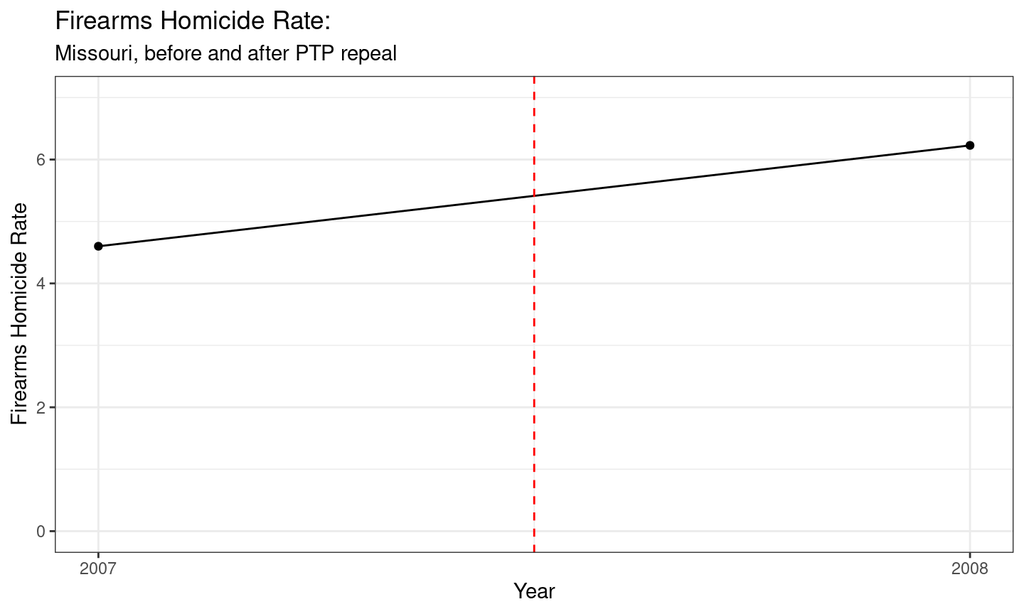

Head to menti.com and enter code \(8518 \ 3260\)

[interactive chart not shown]

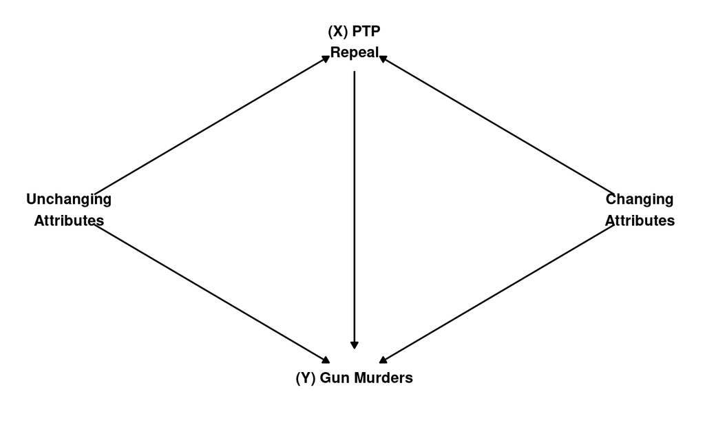

## Example: Gun Laws

Holds all unique, **unchanging** characteristics of Missouri constant…

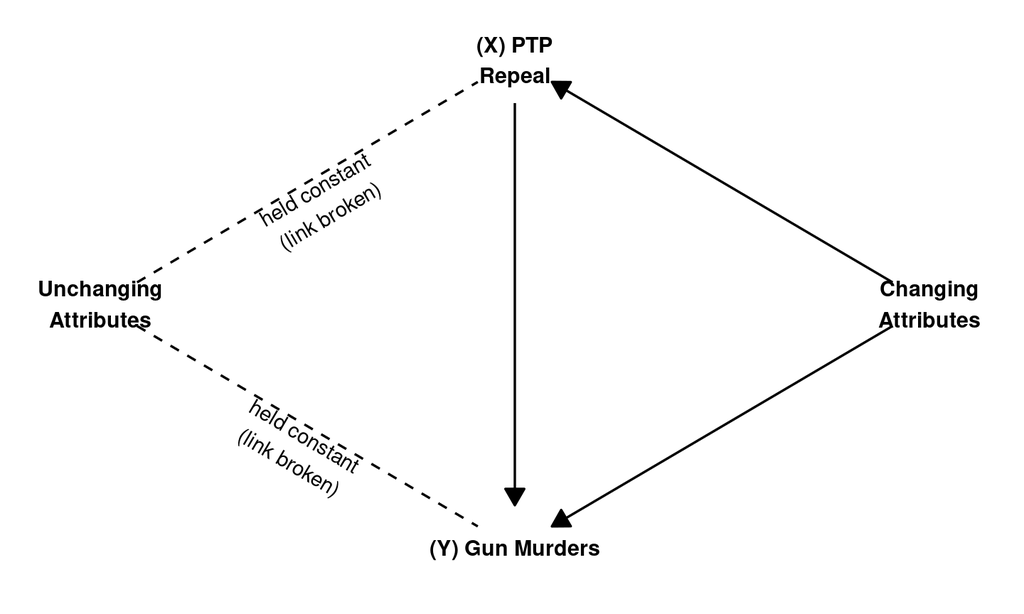

## Example: Gun Laws

But, we have to **assume** that there is nothing else about Missouri that

1. changed around the same time as the PTP repeal
2. and affected Firearms Homicides

No long-term trends, no effects on measurement, no changes in crimes \(\to\) PTP repeal

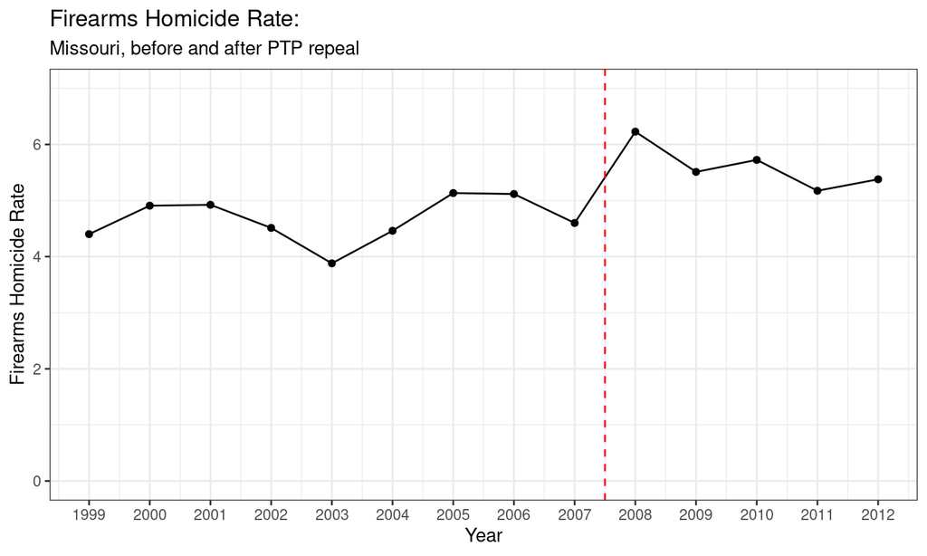

Does this plot make it easier/harder to believe PTP repeal caused more murders? (DISCUSS)

## Example: Gun Laws

- Maybe an upward trend in long term?
- Maybe 2006-2007 was aberration, 2008 a return to trend?
- What else happened in 2008?

Could be that **other things were changing between 2007-2008** that confound relationship between PTP and Murders

## Example: Gun Laws

| State | Time | Murder(Yes) | Murder(No) | Repeal |
| --- | --- | --- | --- | --- |
| Missouri | Before | \(\color{red}{\text{Murders}_{MO,Before}[\text{Repeal}]}\) | \(\color{black}{\text{Murders}_{MO,Before}[\text{No Repeal}]}\) | No |
|  |  |  | \(\neq\not\Downarrow\) |  |
| Missouri | After | \(\color{black}{\text{Murders}_{MO,After}[\text{Repeal}]}\) | \(\color{red}{\text{Murders}_{MO,After}[\text{No Repeal}]}\) | Yes |

It appears that \(\color{red}{\text{Murders}_{MO,After}[\text{No Repeal}]} \neq \\ \color{black}{\text{Murders}_{MO,Before}[\text{No Repeal}]}\)

Because other factors **changing murders**, regardless of repeal

## Example: Gun Laws

What can we do to remove confounding from other variables that **change over time**, like…

- weather patterns (hot weather \(\to\) murders)
- global financial crises/economic shocks
- political events
- Another way to put this question is: what would the trend in gun murders in Missouri have been **had there been no PTP repeal**? What was the **counterfactual trend**?

## Example: Gun Laws

We want to compare the **actual trend** in Missouri:

\(\begin{equation}\begin{split}\text{Trend}_{MO} ={} & \color{black}{\text{Murders}_{MO,After}[\text{Repeal}]} - \\ & \color{black}{\text{Murders}_{MO,Before}[\text{No Repeal}]}\end{split}\end{equation}\)

against the **counterfactual trend** in Missouri:

\(\begin{equation}\begin{split}\color{red}{\text{CF Trend}_{MO}} ={} & \color{red}{\text{Murders}_{MO,After}[\text{No Repeal}]} - \\ & \color{black}{\text{Murders}_{MO,Before}[\text{No Repeal}]}\end{split}\end{equation}\)

\(\small{\begin{equation}\begin{split} = {} & \overbrace{\{\text{Murders}_{MO,After}(\text{Repeal}) - \text{Murders}_{MO,Before}(\text{No Repeal})\}}^{\text{Missouri observed trend}} - \\ & \underbrace{\{\color{red}{\text{Murders}_{MO,After}(\text{No Repeal})} - \text{Murders}_{MO,Before}(\text{No Repeal})\}}_{\color{red}{\text{Missouri counterfactual trend}}}\end{split}\end{equation}}\)

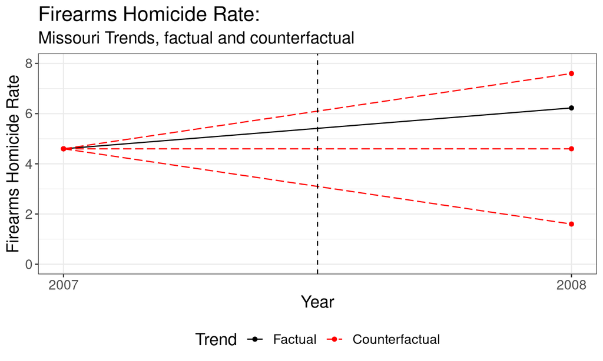

Many possible counterfactual trends…

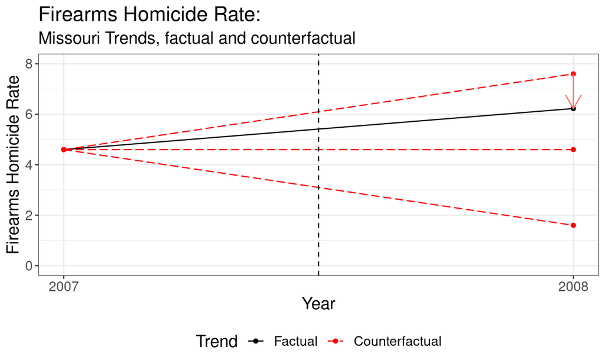

Which counterfactual is right?

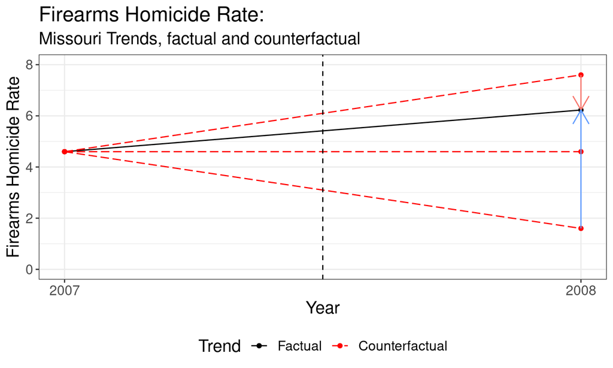

Which counterfactual is right?

## Example: Gun Laws

We can’t know the counterfactual trend in Missouri…

but we can observe the trends in **other states** that **did not change** their gun purchasing laws.

- We can plug in the \(\text{factual TREND}\) in an “untreated” case for the \(\color{red}{\text{counterfactual TREND}}\) in the “treated” case.

[figure not shown]

Arkansas has a different history that Missouri, so there are differences that are unchanging between them.

But, if Arkansas experiences same regional economic, political, cultural, weather trends as Missouri, they might have the **same trends over time**.

Then, we can plug in

\(\small{\begin{equation}\begin{split} = {} & \overbrace{\{\text{Murders}_{MO,After}(\text{Repeal}) - \text{Murders}_{MO,Before}(\text{No Repeal})\}}^{\text{Missouri observed trend}} - \\ & \{\underbrace{\text{Murders}_{AR,After}(\text{No Repeal}) - \text{Murders}_{AR,Before}(\text{No Repeal})\}}_{\text{Arkansas observed trend}}\end{split}\end{equation}}\)

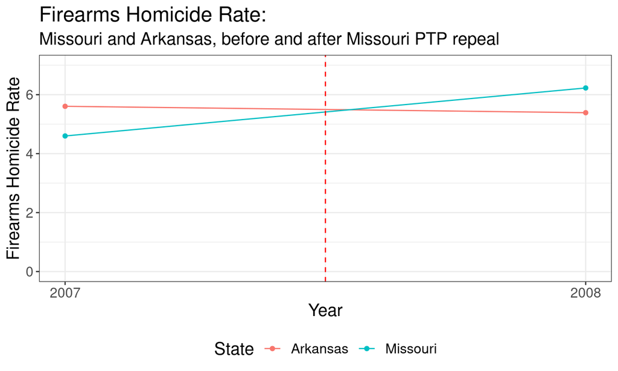

Missouri/Arkansas different in 2007, but if Missouri had same trend (counterfactually) as Arkansas, what would we expect Murders to have done in 2008 w/out the repeal?

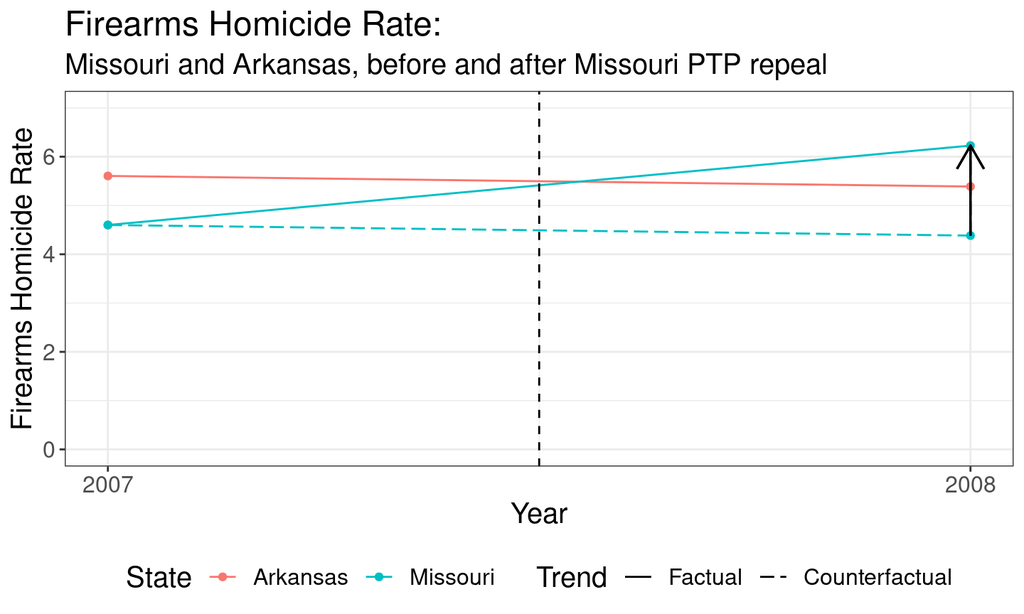

Missouri’s counterfactual trend is **parallel** / same as Arkansas’s factual trend

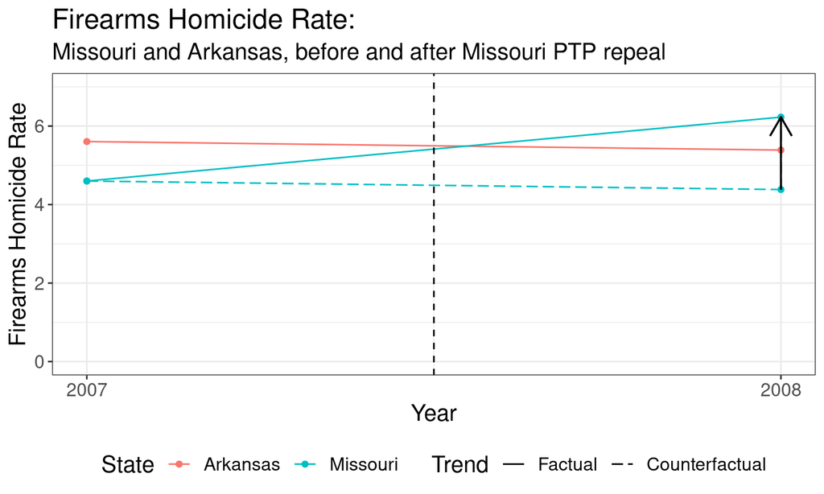

With your neighbors, discuss: Do you believe this is evidence of **causality**? What confounding does this address? What confounding does it not address?

## Difference in Differences

## Design Based Solution:

Like **before and after**, **difference in differences** comparisons are **design** based:

By comparing changes over time in “treated” **and “untreated”** cases:

- hold constant **all unchanging** confounding variables in both treated and untreated cases
- hold constant **all *similarly* changing** confounding variables across treated and untreated cases

Regardless of whether we have thought of those variables, whether we can measure those variables.

## Design: Difference in Differences

**What is it?**

- Compare changes in “treated” cases before and after “treatment” to before and after changes in “untreated” cases

**How does it work?**

- Hold constant **unchanging** attributes of cases (compare same case before and after “treatment”)
- Hold constant variables that **change together** over time in both “treated” and “untreated” cases

## Design: Difference in Differences

Why is it called **difference** in **differences**?

\(\small{\begin{equation}\begin{split} = {} & \overbrace{\{\text{Murders}_{MO,After}(\text{Repeal}) - \text{Murders}_{MO,Before}(\text{No Repeal})\}}^{\text{Missouri observed trend}} - \\ & \{\underbrace{\text{Murders}_{AR,After}(\text{No Repeal}) - \text{Murders}_{AR,Before}(\text{No Repeal})\}}_{\text{Arkansas observed trend}}\end{split}\end{equation}}\)

## Design: Difference in Difference

So:

- \(\mathrm{Difference \ 1} = Murders_{After} - Murders_{Before}\) gives us trend in murders in a \(State\)…
  - holding **unchanging attributes of state** constant (*difference over time*)
- \(\mathrm{Difference \ 2} = \mathrm{Difference \ 1}_{Missouri} - \mathrm{Difference \ 1}_{Arkansas}\) gives us change in murders in \(Treated\) over time, compared to trend in \(Control\)
  - holds **changing attributes of both states** constant (*difference in trends*)

## Design: Difference in Difference

|  | \(Murder_{Before}\) | \(Murder_{After}\) | **First Difference** |
| --- | --- | --- | --- |
| \(\mathrm{Missouri}\) | \(4.6\) | \(6.2\) | \(1.6\) |
| \(\mathrm{Arkansas}\) | \(5.6\) | \(5.4\) | \(-0.2\) |
| **Second Difference** |  |  | \(1.8\) |

## Design: Difference in Differences

### **Confounding Solved**…

All confounding variables (affect whether a PTP repealed; affect firearms homicides) that are **unchanging over time** are held constant

- comparing change over time with-in the same case

All confounding variables that **change the similarly** in “treated” and “untreated” case are held constant.

- By comparing change over time in “treated” to change over time in “control”

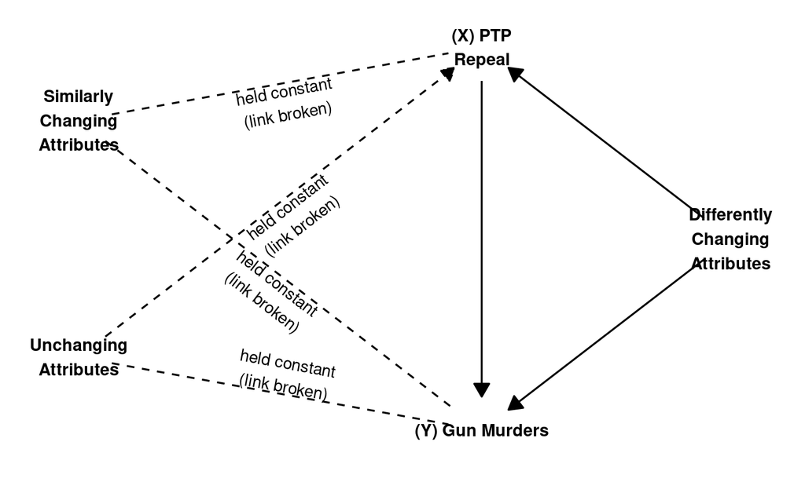

## Design: Difference in Differences

In order to infer \(X\) causes \(Y\) if \(X,Y\) correlated in difference-in-differences comparison…

### **Assumption**

- we assume the observed **trend** in \(Y\) for “untreated” case is **equal to** the “counterfactual trend” in \(Y\) for the “treated” case.
- Equivalently: we assume “treated” and “untreated” have the “parallel trends” in \(Y\).
- Equivalently: **no variables** that affect \(Y\) and **change over time differently** in “treated” and “untreated” cases

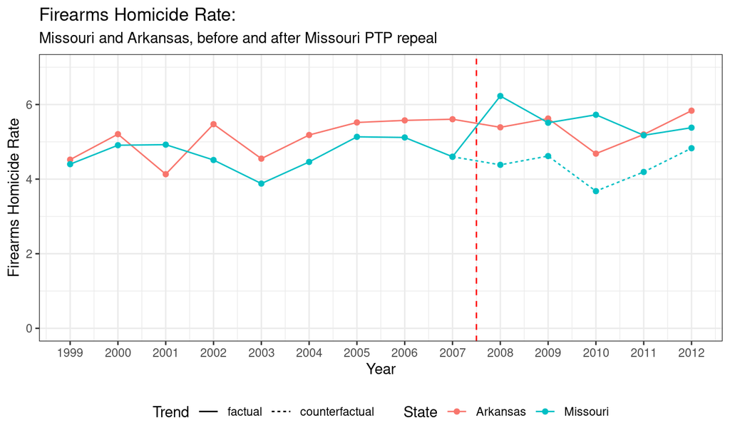

Do you believe assumption of parallel trends?

## Design: Difference in Differences

### **Confounding UNSolved**…

- Arkansas and Missouri murder rates mostly move together before 2007.
- But large change in AR in 2001/2002 not in MO
- But in 2007, before law took effect, murders dipped

Perhaps there is some things that affect murder rates that change differently in these two states.

## Design: Difference in Differences

When is the assumption plausible?

- We can check to see if cases share trends **before** treatment, but does not prove they would have shared trends **after** treatment
- We should compare cases that experience many similar changes over time: comparing Missouri to British Columbia may not be helpful.

| Solution | How Bias Solved | Which Bias Removed | Assumes | Internal Validity | External Validity |
| --- | --- | --- | --- | --- | --- |
| Experiment | Randomization Breaks \(W \rightarrow X\) link | **All** confounding variables | 1. \(X\) is random 2. Change only \(X\) | Highest | Lowest |
| Conditioning | Hold confounders constant | Only variables conditioned on | see above | Lowest | Highest |
| Before and After | Hold confounders constant | variables unchanging over time | No confounders change w/ \(X\) | Lower | Higher |
| Diff in Diff | Hold confounders constant | unchanging and similarly changing | Parallel trends / no differently changing | Higher | Lower |

## Application

## Trump Rallies and Police Bias

[Grosjean et al (2023)](https://doi.org/10.1093/qje/qjac037) investigate:

Did Trump’s messaging at rallies affect police discrimination against racial minorities?

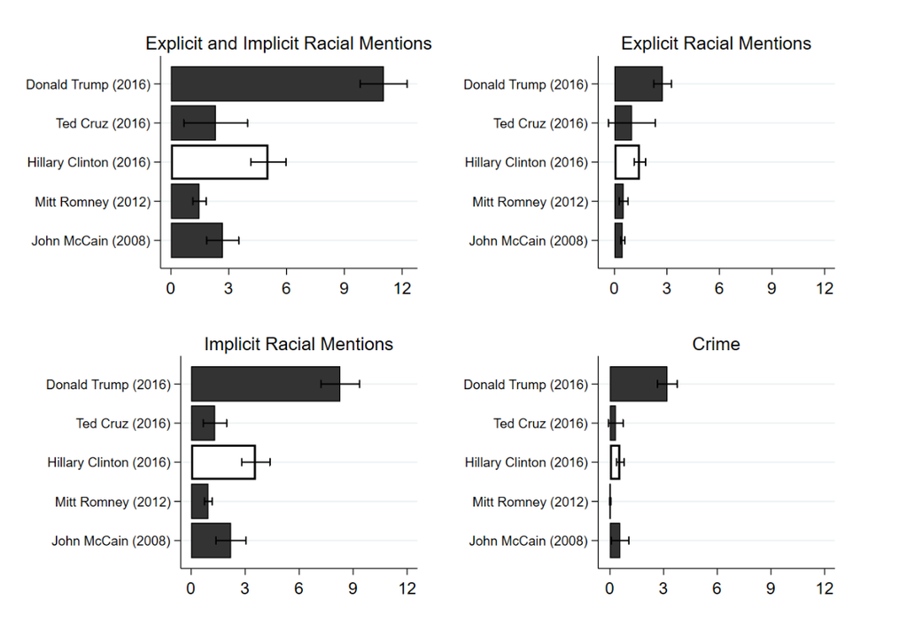

## Trump Rallies and Police Bias

Data:

- ~35 million police stops between 2015-2017 in 1474 counties, including race of person stopped
  - racial bias measured as different rate of stopping racial minorities vs whites
- Campaign rally location and dates

## Trump Rallies and Police Bias

**What might be some confounding variables if we just compared police bias in counties with rallies vs. no rallies?**

**What might be some confounding variables if we just compared police bias in counties before and after rallies?**

## Trump Rallies and Police Bias

Authors can solve these problem using a **difference-in-differences**:

- were the changes in police discrimination **greater** in places with **Trump Rallies** (“treated”) than in places without **without Rallies** (“untreated”)

## Trump Rallies and Police Bias

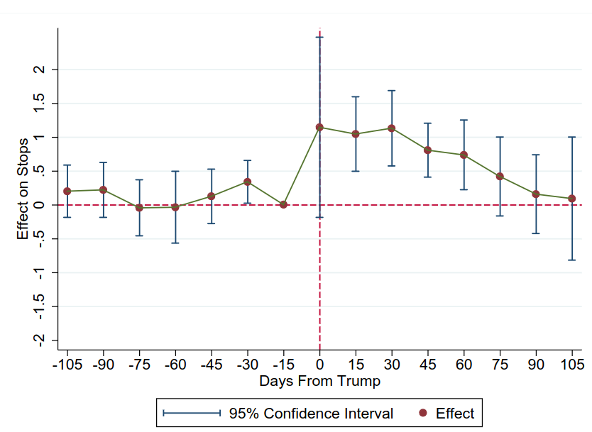

Comparing \(\text{Rallies} - \text{No Rallies}\)

## Trump Rallies and Police Bias

- Can’t be confounding due to unchanging differences b/t places visited/not visited by Trump
- Can’t be confounding due to changing national events (compare rally/no rally places on the same dates)
- Can’t be confounding due to changing behavior of minorities (show no changes)

With reasonable assumptions (no different trends over a few weeks in places with rallies and without rallies), rallies cause police discrimination.